# Klasteryzacja

## Konfiguracja

Użyjemy standardowych bibliotek oraz dodatkowo:

- Plotly - do wizualizacji
- UMAP - redukcja wymiarowości

```python
%matplotlib inline

import matplotlib.pyplot as plt
import numpy as np
import pandas as pd
import sklearn


sklearn.set_config(transform_output="pandas")
```

## Analiza muzyki ze Spotify

Spotify w swoim API oferuje automatyczną [ekstrakcję cech z piosenek](https://developer.spotify.com/documentation/web-api/reference/get-audio-features), których można następnie użyć do wielu ciekawych analiz, jak np. [tutaj](https://rpubs.com/PeterDola/SpotifyTracks) lub [tutaj](https://rstudio-pubs-static.s3.amazonaws.com/604869_8399a2cf0e4a419da6272452c3d6a6d3.html). Datasetów jest wiele, z czego jednym z największych [jest dostępny tutaj na Kaggle](https://www.kaggle.com/datasets/yamaerenay/spotify-dataset-19212020-600k-tracks?select=tracks.csv) i zawiera ponad 600 tysięcy piosenek.

Cechy zwracane przez API to m. in. akustyczność, taneczność, energia, głośność czy długość piosenki. Pełna lista cech jest dostępna [w dokumentacji](https://developer.spotify.com/documentation/web-api/reference/get-audio-features). Są to bardzo dobre cechy do uczenia maszynowego - niewielka wymiarowość i tylko numeryczne. Wadą jest pewna dość mocna korelacja w niektórych podgatunkach muzycznych, ale akurat to w przypadku klasteryzacji takich danych jest całkiem ok, i może prowadzić do sensownych wniosków.

Spotify definiuje i wykorzystuje ponad 125 gatunków muzycznych, które na dodatek są dość dyskusyjne i płynne. Przykładowo, według różnych klasyfikacji Powerwolf, Ensiferum i Alestorm mogą wylądować w tym samym worku, pomimo zdecydowanie różnej muzyki. Klasteryzacja pozwala tworzyć "płynne" tagi, klasyfikując muzykę w dużo bardziej zniuansowany sposób.

**Uwaga:** zgodnie z licencją API danych nie można używać do treningu modeli ML. Oczywiście tego typu licencje nie dotyczą użytku prywatnego ani zastosowań naukowych, co wynika z ogólnych przepisów. Należy jednak pamiętać, że takich modeli nie wolno w żaden sposób publikować ani wykorzystywać komercyjnie.

**Zadanie 1 (2.5 punktu)**

1. Ściągnij pliki `artists.csv` oraz `tracks.csv` z Kaggle'a.
2. Załaduj pliki `artists.parquet` i `tracks.parquet` do zmiennych `df_artists` i `df_tracks`.
3. Usuń wiersze z wartościami brakującymi z obu ramek danych.
4. Ponad 600 tysięcy piosenek to zdecydowanie za dużo, a na dodatek przeważająca większość z nich to drobni, mało znani artyści. Aby to zweryfikować, narysuj histogramy popularności artystów oraz piosenek. Użyj 100 kubełków (bins). Pamiętaj o tytułach wykresów.
5. Dokonaj filtrowania:
   - pozostaw artystów z popularnością >= 55
   - pozostaw piosenki z popularnością >= 55
   - usuń piosenki trwające powyżej 600000 ms (10 minut)
   - użyj funkcji `remove_weird_genres()`, żeby usunąć artystów z ekstremalnie rzadkich gatunków muzycznych
   - użyj funkcji `filter_english_only()`, aby pozostawić tylko anglojęzyczne tytuły
6. Użyj podanej funkcji `extract_artist_id()` na ramce z piosenkami, która dodaje kolumnę `main_artist_id`.
7. Połącz ramki w jedną, `df_songs`, z wszystkimi informacjami:
   - użyj kolumn `main_artist_id` (ramka z piosenkami) oraz `id` (ramka z artystami)
   - przyda się `pd.merge()`
   - Pandas automatycznie dodaje sufiksy do kolumn (argument `suffixes`), żeby rozróżnić kolumny po takiej operacji JOIN
   - domyślnie są to mało znaczące `_x` i `_y`, zmień je na `_track` i `_artist`
8. Usuń duplikaty wedle kolumn `name_track` oraz `name_artist`.
9. Mamy kolumny z danymi, które identyfikują piosenki: nazwa piosenki, artysta, gatunki muzyczne. Nie są one jednak użyteczne do samej klasteryzacji. Wyodrębnij je do osobnej ramki `df_songs_info`.

```
songs_info_cols = [
    "name_track",
    "name_artist",
    "genres"
]
```

10. Stwórz nową ramkę `df_songs_features`, pozostawiając tylko kolumny z cechami do klasteryzacji:

```
songs_features_cols = [
    "explicit",
    "loudness",
    "mode",
    "speechiness",
    "acousticness",
    "instrumentalness",
    "liveness",
    "valence",
    "tempo",
]
```

11. Wypisz finalną liczbę piosenek (rozmiar zbioru).

**Uwaga:** jeżeli notebook będzie wykonywał się zbyt długo, to można ustawić wyższy próg popularności, żeby uzyskać mniejszy podzbiór najbardziej popularnych piosenek.

```python
import ast
from fast_langdetect import detect as detect_language


def extract_artist_id(df_tracks: pd.DataFrame) -> pd.DataFrame:
    df_tracks["main_artist_id"] = df_tracks["id_artists"].apply(
        lambda x: ast.literal_eval(x)[0]
    )
    return df_tracks


def remove_weird_genres(df_songs: pd.DataFrame) -> pd.DataFrame:
    all_genres = []
    for song_genres in df_songs["genres"]:
        all_genres.extend(ast.literal_eval(song_genres))

    df_genres = pd.Series(all_genres).value_counts().reset_index()

    weird_genres = df_genres.loc[df_genres["count"] < 150, "index"]
    weird_genres = set(weird_genres.tolist())

    to_keep = []
    for song_genres in df_songs["genres"]:
        song_genres = set(ast.literal_eval(song_genres))
        not_all_weird = len(song_genres - weird_genres) > 0
        to_keep.append(not_all_weird)

    df_songs = df_songs[to_keep]
    return df_songs


def filter_english_only(df_songs: pd.DataFrame) -> pd.DataFrame:
    english = [
        detect_language(title[:100], low_memory=False)["lang"] == "en"
        for title in df_songs["name"]
    ]
    return df_songs[english]
```

```python
df_artists = pd.read_csv("artists.csv")
df_tracks = pd.read_csv("tracks.csv")
```

```python
df_artists.to_parquet("artists.parquet")
df_tracks.to_parquet("tracks.parquet")
```

```python
df_artists = pd.read_parquet("artists.parquet")
df_tracks = pd.read_parquet("tracks.parquet")
```

```python
df_artists = df_artists.dropna()
df_tracks = df_tracks.dropna()
```

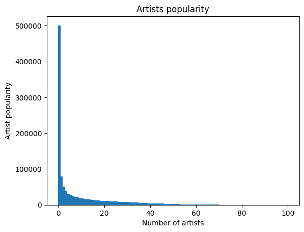

```python
df_artists["popularity"].plot.hist(
    title="Artists popularity",
    bins=100,
    ylabel="Artist popularity",
    xlabel="Number of artists",
)
```

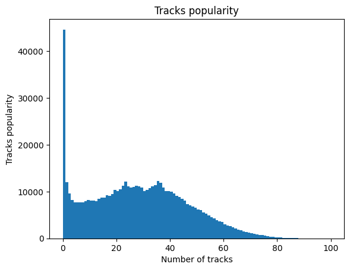

```python
df_tracks["popularity"].plot.hist(
    title="Tracks popularity",
    bins=100,
    ylabel="Tracks popularity",
    xlabel="Number of tracks",
)
```

```python
df_artists = df_artists[df_artists["popularity"] >= 55]
df_tracks = df_tracks[df_tracks["popularity"] >= 55]
df_tracks = df_tracks[df_tracks["duration_ms"] <= 600000]

df_artists = remove_weird_genres(df_artists)
df_tracks = filter_english_only(df_tracks)
```

```python
df_tracks = extract_artist_id(df_tracks)
```

```python
df_songs = pd.merge(
    df_tracks,
    df_artists,
    left_on="main_artist_id",
    right_on="id",
    suffixes=("_track", "_artist"),
)
```

```python
df_songs = df_songs.drop_duplicates(subset=["name_track", "name_artist"])
```

```python
songs_info_cols = ["name_track", "name_artist", "genres"]
df_songs_info = df_songs[songs_info_cols].copy()
```

```python
songs_features_cols = [
    "explicit",
    "loudness",
    "mode",
    "speechiness",
    "acousticness",
    "instrumentalness",
    "liveness",
    "valence",
    "tempo",
]
df_songs_features = df_songs[songs_features_cols].copy()
```

```python
print(f"Songs number after filtration: {df_songs.shape[0]}")
```

```
Songs number after filtration: 17471
```

Mamy teraz przygotowane dane, więc można brać się za klasteryzację. Nasz zbiór jest dość duży, nawet po dokonanym ostrym filtrowaniu, więc potrzebujemy skalowalnych algorytmów klasteryzacji. Klasteryzacja hierarchiczna zdecydowanie odpada, pozostają więc k-means, DBSCAN i HDBSCAN. Co prawda hiperparametry do DBSCAN ciężko jest dobrać, ale zobaczymy, jak można to zrobić.

Zanim przejdziemy do klasteryzacji, trzeba ustandardyzować nasze dane. Po tym trzeba przeprowadzić też globalną analizę naszego zbioru, jak na przykład rozkłady cech, albo zwizualizować go z pomocą redukcji wymiaru. Jest to ważne, bo przy późniejszej analizie klastrów musimy wiedzieć, czy klastry w ogóle różnią się od ogółu naszych danych.

**Zadanie 2 (1 punkt)**

1. Dokonaj standaryzacji cech, tworząc ramkę `X`.
2. Uzupełnij kod klasy `ClusteringVisualizer`, która przyjmuje dane, numery klastrów dla poszczególnych punktów (opcjonalne), i przedstawia wykresy PCA oraz UMAP:
   - zredukuj dane do 2 wymiarów
   - pamiętaj o `random_state=0`
   - [dokumentacja UMAP](https://umap-learn.readthedocs.io/en/latest/basic_usage.html)
   - przekaż `low_memory=False` dla UMAP
   - ze względu na specyfikę implementacji, wykorzystanie `.fit_transform()` będzie zauważalnie szybsze od osobnych `.fit()` i `.transform()`
   - skomentuj:
     - czy w przypadku PCA widać jakąś strukurę klastrów?
     - czy widać ją w przypadku UMAP?
     - czy redukcja nieliniowa dała lepsze, czy gorsze wyniki od liniowego PCA w wizualizacji?

Czemu klasa, a nie funkcja? UMAP, jak praktycznie wszystkie metody nieliniowej redukcji wymiaru, wykorzystuje graf najbliższych sąsiadów. Jeżeli obliczymy dane po redukcji raz, i zapiszemy jako atrybut, to później będziemy mogli uniknąć liczenia tego wielokrotnie. Zapisanie tych wyników zaoszczędzi nam wiele minut :)

```python
from sklearn.preprocessing import StandardScaler

scaler = StandardScaler()
X = scaler.fit_transform(df_songs_features)
```

```python
from typing import Optional

from IPython.display import display
from sklearn.decomposition import PCA
from umap.umap_ import UMAP


class ClusteringVisualizer:
    def __init__(self, X: np.ndarray | pd.DataFrame):
        self.X_array = X.to_numpy() if isinstance(X, pd.DataFrame) else X

        # PCA
        self.X_pca = PCA(n_components=2, random_state=0).fit_transform(self.X_array)
        self.X_pca = self.X_pca.to_numpy()

        # UMAP
        self.X_umap = UMAP(low_memory=False, random_state=0).fit_transform(self.X_array)

    def visualize(self, labels: Optional[np.ndarray] = None):
        if labels is None:
            labels = np.ones(self.X_array.shape[0])

        fig, axes = plt.subplots(1, 2, figsize=(10, 4))

        axes[0].scatter(
            self.X_pca[:, 0], self.X_pca[:, 1], c=labels, cmap="tab10", s=10, alpha=0.6
        )
        axes[0].set_title("PCA")

        axes[1].scatter(
            self.X_umap[:, 0],
            self.X_umap[:, 1],
            c=labels,
            cmap="tab10",
            s=10,
            alpha=0.6,
        )
        axes[1].set_title("UMAP")

        fig.suptitle("Clustering visualization")
        plt.tight_layout()
        plt.show()
```

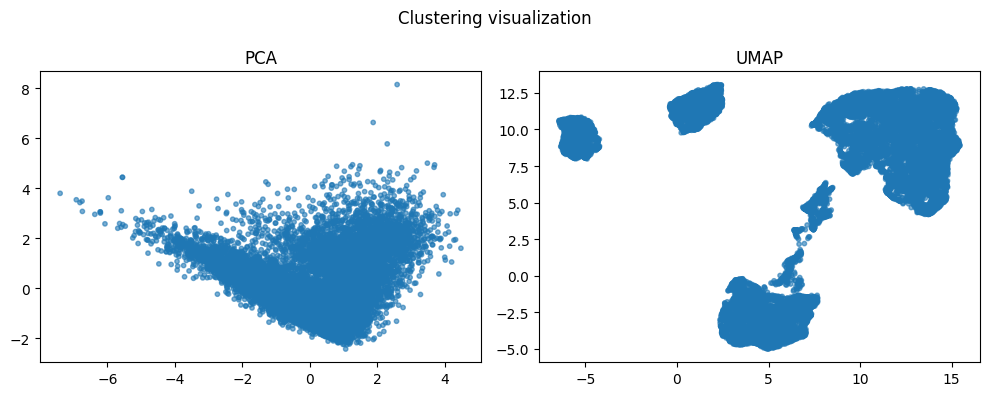

```python
clustering_visualizer = ClusteringVisualizer(X)
clustering_visualizer.visualize()
```

W przypadku `PCA` rozkład zmiennych jest dość mocno zgrupowany w jednym miejscu w formie dużego klastra oraz szumu na około. Wydaje mi się że tu będzie ciężko przeprowadzić klasteryzacje.

`UMAP` sprawdził się dużo lepiej dla tego zbioru danych. Na pierwszy rzut oka możemy wyróżnić 4 lub 5 klastrów.

Teraz przeanalizujemy nasz zbiór. Posłużą nam do tego poniżej zdefiniowane klasy `KMeansAnalzyer`, `DBSCANAnalyzer` i `HDBSCANAnalyzer`. Metoda `.analyze_clustering()` dla każdego klastra:

1. Wypisuje liczbę klastrów, oraz informację o szumie (dla DBSCAN i HDBSCAN).
2. Wypisuje wartość metryki [Calinski-Harabasz index](https://scikit-learn.org/stable/modules/generated/sklearn.metrics.calinski_harabasz_score.html), jeżeli liczba klastrów to co najmniej 2. Dla DBSCAN i HDBSCAN uwzględniamy tylko punkty z klastrów, ignorując szum.
3. Rysuje wykres klastrów po redukcji z PCA oraz UMAP.
4. Tworzy [wykres radowy (radar chart)](https://plotly.com/python/radar-chart/). Pozwala on wygodnie porównać wartości średnie dla poszczególnych cech.
5. Wypisuje piosenki i artystów reprezentujące klaster:
   - dla k-means jest to 10 punktów najbliższych do centroidu
   - dla DBSCAN wybieramy heurystycznie 10 punktów najbliższych do centroidu
   - dla HDBSCAN wybieramy punkty o najwyższym prawdopodobieństwie (nie używamy exemplars, bo jest to bardzo wolne [i mało wygodne](https://github.com/scikit-learn-contrib/hdbscan/issues/304))
6. Wypisuje 10 najczęstszych gatunków muzycznych w klastrze.

Dla DBSCAN i HDBSCAN, które same wykrywają liczbę klastrów i może być ich bardzo dużo, analizowane jest tylko:

- max 10 największych klastrów
- tylko te, które mają co najmniej 100 próbek

Na początek potraktujemy cały nasz zbiór jako jeden wielki klaster dla algorytmu k-means i popatrzymy, co tam się dzieje.

```python
import itertools
from abc import ABC, abstractmethod
from collections import Counter

import plotly.graph_objects as go

from sklearn.cluster import DBSCAN, HDBSCAN, KMeans
from sklearn.metrics import calinski_harabasz_score
from sklearn.neighbors import NearestNeighbors
from sklearn.preprocessing import minmax_scale


class ClusteringAnalyzer(ABC):
    def __init__(
        self, df_songs_info: pd.DataFrame, clustering_visualizer: ClusteringVisualizer
    ):
        self.df_songs_info = df_songs_info
        self.clustering_visualizer = clustering_visualizer

    @abstractmethod
    def analyze_clustering(self, X: pd.DataFrame, clustering) -> None:
        raise NotImplementedError()

    def _get_top_clusters_labels(self, labels: np.ndarray) -> np.ndarray:
        labels = labels[labels != -1]
        label_counts = pd.Series(labels).value_counts()
        label_counts = label_counts[label_counts >= 100]
        top_labels = label_counts.index[:10].values
        return top_labels

    def _create_radar_chart(self, X: pd.DataFrame, label: int) -> None:
        fig = go.Figure()
        vals = minmax_scale(X).mean()
        fig.add_trace(go.Scatterpolar(r=vals, theta=X.columns, fill="toself"))
        fig.update_layout(title_text=f"Cluster {label}", title_x=0.5)
        fig.update_polars(radialaxis=dict(range=[0, 1]))
        fig.show()

    def _get_central_songs(
        self, X: pd.DataFrame, cluster_songs_info: pd.DataFrame, prototype: np.ndarray
    ) -> None:
        n_neighbors = min(10, len(X))
        nn = NearestNeighbors(n_neighbors=n_neighbors, n_jobs=-1)
        nn.fit(X.values)
        _, nn_idxs = nn.kneighbors(prototype)
        nn_idxs = nn_idxs.ravel()
        nn_songs_info = cluster_songs_info.iloc[nn_idxs]
        nn_songs_info = nn_songs_info.drop(columns="genres")
        nn_songs_info.columns = ["Track", "Artist"]
        nn_songs_info = nn_songs_info.reset_index(drop=True)
        display(nn_songs_info)

    def _get_cluster_top_genres(
        self,
        cluster_songs_info: pd.DataFrame,
    ) -> None:
        genres = cluster_songs_info["genres"].values
        genres = [ast.literal_eval(x) for x in genres]
        genres = Counter(itertools.chain(*genres))
        top_genres = genres.most_common(10)
        top_genres = [name for name, count in top_genres]
        print("Top 10 genres in the cluster:", top_genres)


class KMeansAnalyzer(ClusteringAnalyzer):
    def analyze_clustering(self, X: pd.DataFrame, clustering: KMeans) -> None:
        labels = clustering.labels_
        centroids = clustering.cluster_centers_

        print(f"Number of clusters: {max(labels) + 1}")

        if labels.max() >= 2:
            ch_index = calinski_harabasz_score(X, labels)
            print(f"CH-index value: {ch_index:.2f}")

        self.clustering_visualizer.visualize(labels)

        for label in range(0, max(labels) + 1):
            X_cluster = X[labels == label]
            cluster_songs_info = df_songs_info[labels == label]
            centroid = centroids[label].reshape((1, -1))

            print(f"Cluster {label} size: {len(X_cluster)}")
            self._create_radar_chart(X_cluster, label)
            self._get_central_songs(X_cluster, cluster_songs_info, centroid)
            self._get_cluster_top_genres(cluster_songs_info)


class DBSCANAnalyzer(ClusteringAnalyzer):
    def analyze_clustering(self, X: pd.DataFrame, clustering: DBSCAN) -> None:
        labels = clustering.labels_

        noise_num = (labels == -1).sum()
        noise_perc = noise_num / len(X)

        print(f"Number of clusters: {max(labels) + 1}")
        print(f"Percentage of noise points: {100 * noise_perc:.2f}%")

        if labels.max() >= 2:
            X_non_noise = X[labels != -1]
            labels_non_noise = labels[labels != -1]
            ch_index = calinski_harabasz_score(
                X_non_noise,
                labels_non_noise,
            )
            print(f"CH-index value: {ch_index:.2f}")

        self.clustering_visualizer.visualize(labels)

        for label in self._get_top_clusters_labels(labels):
            X_cluster = X[labels == label]
            cluster_songs_info = df_songs_info[labels == label]
            centroid = self._get_cluster_centroid(X_cluster)

            print(f"Cluster {label} size: {len(X_cluster)}")
            self._create_radar_chart(X_cluster, label)
            self._get_central_songs(X_cluster, cluster_songs_info, centroid)
            self._get_cluster_top_genres(cluster_songs_info)

    def _get_cluster_centroid(self, X_cluster: pd.DataFrame) -> np.ndarray:
        centroid = np.mean(X_cluster.values, axis=0)
        return np.array(centroid).reshape((1, -1))


class HDBSCANAnalyzer(ClusteringAnalyzer):
    def analyze_clustering(self, X: pd.DataFrame, clustering: HDBSCAN) -> None:
        labels = clustering.labels_
        probas = clustering.probabilities_

        noise_num = (labels == -1).sum()
        noise_perc = noise_num / len(X)

        print(f"Number of clusters: {max(labels) + 1}")
        print(f"Percentage of noise points: {100 * noise_perc:.2f}%")

        if labels.max() >= 2:
            X_non_noise = X[labels != -1]
            labels_non_noise = labels[labels != -1]
            ch_index = calinski_harabasz_score(
                X_non_noise,
                labels_non_noise,
            )
            print(f"CH-index value: {ch_index:.2f}")

        self.clustering_visualizer.visualize(labels)

        for label in self._get_top_clusters_labels(labels):
            X_cluster = X[labels == label]
            cluster_songs_info = df_songs_info[labels == label]
            cluster_probas = probas[labels == label]

            print(f"Cluster {label} size: {len(X_cluster)}")
            self._create_radar_chart(X_cluster, label)
            self._get_most_probable_songs(X_cluster, cluster_songs_info, cluster_probas)
            self._get_cluster_top_genres(cluster_songs_info)

    def _get_most_probable_songs(
        self,
        X: pd.DataFrame,
        cluster_songs_info: pd.DataFrame,
        cluster_probas: np.ndarray,
    ) -> None:
        top_10_indexes = np.argpartition(cluster_probas, -10)[-10:]
        nn_songs_info = cluster_songs_info.iloc[top_10_indexes]
        nn_songs_info = nn_songs_info.drop(columns="genres")
        nn_songs_info.columns = ["Track", "Artist"]
        nn_songs_info = nn_songs_info.reset_index(drop=True)
        display(nn_songs_info)
```

```
Number of clusters: 1
```

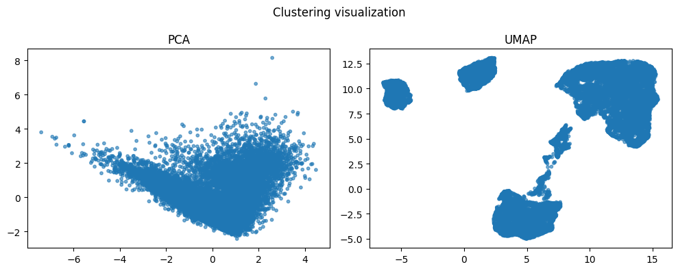

```
Cluster 0 size: 17471
```

|  | Track | Artist |
| --- | --- | --- |
| 0 | Higher Place - Radio Edit | Dimitri Vegas & Like Mike |
| 1 | Odhani (From "Made in China") | Sachin-Jigar |
| 2 | Fake ID | Riton |
| 3 | Just A Lover | Hayden James |
| 4 | It's All About Me | Mýa |
| 5 | Lay It All on Me (feat. Ed Sheeran) | Rudimental |
| 6 | Rather Be (feat. Jess Glynne) | Clean Bandit |
| 7 | Brown Skin | India.Arie |
| 8 | Drive (For Daddy Gene) | Alan Jackson |
| 9 | Happy Now | Kygo |

```
Top 10 genres in the cluster: ['pop', 'rock', 'dance pop', 'post-teen pop', 'rap', 'pop rap', 'hip hop', 'classic rock', 'mellow gold', 'soft rock']
```

```python
from sklearn.cluster import KMeans


clustering = KMeans(n_clusters=1, n_init="auto", random_state=0)
clustering.fit(X)

kmeans_analyzer = KMeansAnalyzer(df_songs_info, clustering_visualizer)
kmeans_analyzer.analyze_clustering(X, clustering)
```

**Zadanie 3 (1.5 punktu)**

1. Wytrenuj k-means dla 3 klastrów.
2. Zwizualizuj wyniki za pomocą PCA i UMAP. Jako kolor punktów (np. parametr `c` w `plt.scatter()`) przekaż numery klastrów dla punktów.
3. Dokonaj opisu i analizy wynikowych klastrów, na przykład:
   - czy reprezentują jakieś konkretne grupy muzyczne?
   - na ile "konkretne", sensowne są klastry?
   - czy jest widoczna separacja klastrów, czy różnią się od siebie?
4. Dokonaj tuningu liczby klastrów:
   - sprawdź wartości z zakresu [5, 20] - w końcu wiemy, że gatunków jest sporo, i klastrów powinno też być więcej
   - dla każdej wartości sprawdź wartość metryki [Calinski-Harabasz index](https://scikit-learn.org/stable/modules/generated/sklearn.metrics.calinski_harabasz_score.html)
   - przedstaw wykres liniowy (line plot) wartości metryki
   - wybierz model o najwyższej wartości metryki
   - zwizualizuj wyniki z pomocą PCA i UMAP
   - dokonaj interpretacji jego klastrów
   - skomentuj:
     - czy klastry są faktycznie lepiej interpretowalne po tuningu?
     - czy wysokość CH-index faktycznie odpowiada jakości klasteryzacji?

```
Number of clusters: 3
CH-index value: 3101.16
```

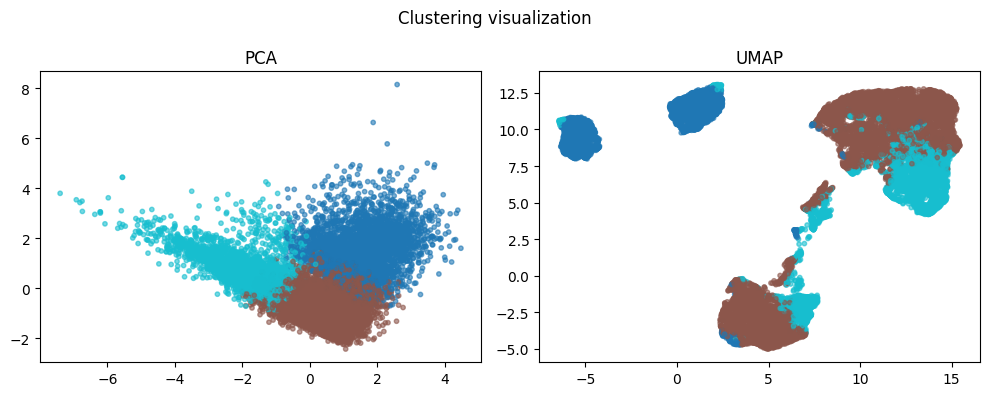

```
Cluster 0 size: 3533
```

|  | Track | Artist |
| --- | --- | --- |
| 0 | Soleil | Roméo Elvis |
| 1 | Worst Behavior | Drake |
| 2 | Broken Clocks | SZA |
| 3 | okay | LANY |
| 4 | Luxury | Azealia Banks |
| 5 | Lost | Frank Ocean |
| 6 | just like magic | Ariana Grande |
| 7 | All Night (feat. Knox Fortune) | Chance the Rapper |
| 8 | Augenblick (feat. Summer Cem) | KC Rebell |
| 9 | Guerrilla Radio | Rage Against The Machine |

```
Top 10 genres in the cluster: ['rap', 'hip hop', 'pop rap', 'trap', 'pop', 'gangster rap', 'dance pop', 'southern hip hop', 'east coast hip hop', 'hardcore hip hop']
Cluster 1 size: 10052
```

|  | Track | Artist |
| --- | --- | --- |
| 0 | Keeping Your Head Up | Birdy |
| 1 | Rather Be (feat. Jess Glynne) | Clean Bandit |
| 2 | Fake ID | Riton |
| 3 | Ishq Tera | Guru Randhawa |
| 4 | Penny Lane - Remastered 2015 | The Beatles |
| 5 | Whine Up (feat. Elephant Man) - English Version | Kat Deluna |
| 6 | Starlight | Taylor Swift |
| 7 | Cheerleader - Felix Jaehn Remix Radio Edit | OMI |
| 8 | We're Good | Dua Lipa |
| 9 | All I Am | Jess Glynne |

```
Top 10 genres in the cluster: ['pop', 'rock', 'dance pop', 'post-teen pop', 'modern rock', 'pop rock', 'classic rock', 'album rock', 'soft rock', 'mellow gold']
Cluster 2 size: 3886
```

|  | Track | Artist |
| --- | --- | --- |
| 0 | Frozen | Madonna |
| 1 | (You Make Me Feel Like) A Natural Woman | Aretha Franklin |
| 2 | As Tears Go By - Mono Version | The Rolling Stones |
| 3 | Stuff Is Way | They Might Be Giants |
| 4 | The Last Waltz | Engelbert Humperdinck |
| 5 | Tenerife Sea | Ed Sheeran |
| 6 | It's All Over Now Baby Blue | Marianne Faithfull |
| 7 | Only Love Can Break Your Heart | Neil Young |
| 8 | The Most Beautiful Thing | Bruno Major |
| 9 | Witchcraft | Frank Sinatra |

```
Top 10 genres in the cluster: ['pop', 'rock', 'classic rock', 'mellow gold', 'adult standards', 'soft rock', 'folk rock', 'album rock', 'post-teen pop', 'dance pop']
```

```python
from sklearn.cluster import KMeans


clustering = KMeans(n_clusters=3, n_init="auto", random_state=0)
clustering.fit(X)


kmeans_analyzer = KMeansAnalyzer(df_songs_info, clustering_visualizer)
kmeans_analyzer.analyze_clustering(X, clustering)
```

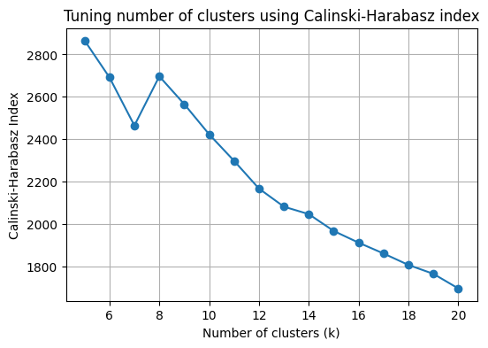

```python
num_clusters_range = range(5, 21)

calinski_scores = []
for num_clusters in num_clusters_range:
    kmeans_model = KMeans(n_clusters=num_clusters, n_init="auto", random_state=0)
    kmeans_model.fit(X)
    score = calinski_harabasz_score(X, kmeans_model.labels_)
    calinski_scores.append(score)

# Wykres
plt.figure(figsize=(6, 4))
plt.plot(num_clusters_range, calinski_scores, marker="o", color="tab:blue")
plt.xlabel("Number of clusters (k)")
plt.ylabel("Calinski-Harabasz Index")
plt.title("Tuning number of clusters using Calinski-Harabasz index")
plt.grid(True)
plt.show()
```

```
Najwyższa wartość CH-index dla n_clusters=5
Number of clusters: 5
CH-index value: 2865.80
```

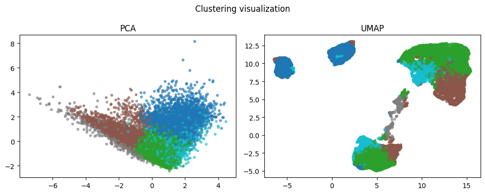

```
Cluster 0 size: 3281
```

|  | Track | Artist |
| --- | --- | --- |
| 0 | Soleil | Roméo Elvis |
| 1 | okay | LANY |
| 2 | Broken Clocks | SZA |
| 3 | Augenblick (feat. Summer Cem) | KC Rebell |
| 4 | just like magic | Ariana Grande |
| 5 | Worst Behavior | Drake |
| 6 | All Night (feat. Knox Fortune) | Chance the Rapper |
| 7 | Lost | Frank Ocean |
| 8 | SEC | Josman |
| 9 | Gang | Mister V |

```
Top 10 genres in the cluster: ['rap', 'hip hop', 'pop rap', 'trap', 'pop', 'gangster rap', 'southern hip hop', 'dance pop', 'east coast hip hop', 'hardcore hip hop']
Cluster 1 size: 7885
```

|  | Track | Artist |
| --- | --- | --- |
| 0 | Defenceless | Louis Tomlinson |
| 1 | Strangers Like Me | Phil Collins |
| 2 | Hold On (feat. Cheat Codes) - Radio Edit | Moguai |
| 3 | Here For A Good Time | George Strait |
| 4 | Ishq Tera | Guru Randhawa |
| 5 | Forever Young | John De Sohn |
| 6 | Not Alone | Linkin Park |
| 7 | TOOTIMETOOTIMETOOTIME | The 1975 |
| 8 | Black Hole | Griff |
| 9 | Whine Up (feat. Elephant Man) - English Version | Kat Deluna |

```
Top 10 genres in the cluster: ['pop', 'rock', 'dance pop', 'post-teen pop', 'pop rock', 'classic rock', 'modern rock', 'soft rock', 'album rock', 'mellow gold']
Cluster 2 size: 3420
```

|  | Track | Artist |
| --- | --- | --- |
| 0 | (You Make Me Feel Like) A Natural Woman | Aretha Franklin |
| 1 | Frozen | Madonna |
| 2 | As Tears Go By - Mono Version | The Rolling Stones |
| 3 | Tenerife Sea | Ed Sheeran |
| 4 | Only Love Can Break Your Heart | Neil Young |
| 5 | It's All Over Now Baby Blue | Marianne Faithfull |
| 6 | The Last Waltz | Engelbert Humperdinck |
| 7 | The One That Got Away - Acoustic | Katy Perry |
| 8 | Forever Like That | Ben Rector |
| 9 | The Load-Out - 2018 Remaster | Jackson Browne |

```
Top 10 genres in the cluster: ['pop', 'rock', 'mellow gold', 'adult standards', 'classic rock', 'soft rock', 'post-teen pop', 'folk rock', 'dance pop', 'album rock']
Cluster 3 size: 659
```

|  | Track | Artist |
| --- | --- | --- |
| 0 | Talking | Elderbrook |
| 1 | Shake | The Head And The Heart |
| 2 | Chances | The Strokes |
| 3 | Sail | AWOLNATION |
| 4 | Calling Elvis | Dire Straits |
| 5 | About Today | The National |
| 6 | House Of Cards | Radiohead |
| 7 | Sun Models (feat. Madelyn Grant) | ODESZA |
| 8 | Just Like Honey | The Jesus and Mary Chain |
| 9 | istanbul freestyle | Pashanim |

```
Top 10 genres in the cluster: ['rock', 'alternative rock', 'classic rock', 'art rock', 'permanent wave', 'album rock', 'modern rock', 'alternative metal', 'indie rock', 'edm']
Cluster 4 size: 2226
```

|  | Track | Artist |
| --- | --- | --- |
| 0 | The Sound | The 1975 |
| 1 | Rewrite The Stars (with James Arthur & Anne-Ma... | James Arthur |
| 2 | Rewrite The Stars | James Arthur |
| 3 | My Body | Young the Giant |
| 4 | Can't Get Enough | J. Cole |
| 5 | Pale Shelter - 2nd Single Version | Tears For Fears |
| 6 | All This Love (feat. Harlœ) | Robin Schulz |
| 7 | Happiness | Alexis Jordan |
| 8 | I Gotta Feeling | Black Eyed Peas |
| 9 | Some Kind Of Wonderful - Remastered 1999 | Grand Funk Railroad |

```
Top 10 genres in the cluster: ['rock', 'pop', 'dance pop', 'post-teen pop', 'modern rock', 'classic rock', 'pop rock', 'pop rap', 'soft rock', 'album rock']
```

```python
best_n_clusters = num_clusters_range[np.argmax(calinski_scores)]
print(f"Najwyższa wartość CH-index dla n_clusters={best_n_clusters}")

best_kmeans = KMeans(n_clusters=best_n_clusters, n_init="auto", random_state=0)
best_kmeans.fit(X)

# Analiza najlepszego modelu
kmeans_analyzer = KMeansAnalyzer(df_songs_info, clustering_visualizer)
kmeans_analyzer.analyze_clustering(X, best_kmeans)
```

Po tunningu klastry są wyniki są lepiej interpretowalne. Wiele najbardziej popularnych gatunków muzycznych z danego klastra są podobne i mają więcej sensu Nie do końca. Choć CH-index teoretycznie mierzy „jakość” klastrów, to w tym przypadku największą wartość uzyskaliśmy przy 3 klastrach (CH-index 3101), ale interpretacyjnie podział na 3 klastry był zbyt ogólny i mniej użyteczny.

Problem z k-means jest taki, że wykrywa tylko klastry sferyczne. W przypadku zbiorów, w których klastry mogą być mocno wymieszane, będzie to szczególnym problemem. Tak może być tutaj - w końcu mamy co najmniej kilka podgatunków rocka i popu, które są zbliżone do siebie. Mamy też dość egzotyczne podgatunki takie jak "art rock" czy "rock en espanol", które być może są nieliczne i stanowią de facto szum.

Do takich sytuacji doskonale nadaje się DBSCAN. Ma co prawda większą złożoność, ale dla danych tego rozmiaru jest to jeszcze akceptowalne. Sprawdźmy, jak działa dla domyślnych hiperparametrów - epsilon 0.5 i min_samples 5.

```
Number of clusters: 105
Percentage of noise points: 61.22%
CH-index value: 34.44
```

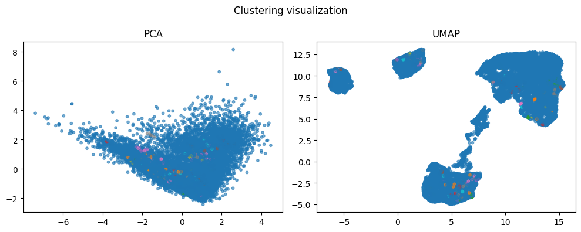

```
Cluster 1 size: 4799
```

|  | Track | Artist |
| --- | --- | --- |
| 0 | TOOTIMETOOTIMETOOTIME | The 1975 |
| 1 | Black | Dierks Bentley |
| 2 | Not Alone | Linkin Park |
| 3 | pink skies | LANY |
| 4 | Higher Place - Radio Edit | Dimitri Vegas & Like Mike |
| 5 | Look Into My Eyes | Brando |
| 6 | Forever Young | John De Sohn |
| 7 | Strangers Like Me | Phil Collins |
| 8 | Defenceless | Louis Tomlinson |
| 9 | Lay It All on Me (feat. Ed Sheeran) | Rudimental |

```
Top 10 genres in the cluster: ['pop', 'rock', 'dance pop', 'post-teen pop', 'pop rock', 'modern rock', 'contemporary country', 'soft rock', 'classic rock', 'mellow gold']
Cluster 9 size: 1221
```

|  | Track | Artist |
| --- | --- | --- |
| 0 | Ocean Drive | Duke Dumont |
| 1 | Counting Stars | OneRepublic |
| 2 | React | The Pussycat Dolls |
| 3 | OK | Robin Schulz |
| 4 | Drink to That All Night | Jerrod Niemann |
| 5 | Summer On You (feat. Wulf) | Sam Feldt |
| 6 | Don't Go Away Mad (Just Go Away) | Mötley Crüe |
| 7 | Come As You Are | Nirvana |
| 8 | We Are One (Ole Ola) [The Official 2014 FIFA W... | Pitbull |
| 9 | Going Dumb (with Stray Kids) | Alesso |

```
Top 10 genres in the cluster: ['pop', 'dance pop', 'rock', 'post-teen pop', 'pop dance', 'edm', 'tropical house', 'modern rock', 'alternative metal', 'pop rock']
```

```python
from sklearn.cluster import DBSCAN

clustering = DBSCAN(n_jobs=-1)
clustering.fit(X)

dbscan_analyzer = DBSCANAnalyzer(df_songs_info, clustering_visualizer)
dbscan_analyzer.analyze_clustering(X, clustering)
```

Mamy niesamowicie dużo klastrów oraz szumu - niedobrze! Oznacza to, że zbyt ciężko jest "dotrzeć" do kolejnych punktów, żeby stworzyć klastry. Mogą być tego dwie przyczyny:

- zbyt mały promień epsilon
- zbyt duże min_samples

Biorąc pod uwagę, że minimalna liczba próbek to zaledwie 5, to to drugie nie występuje. Musimy zatem zwiększyć promień. Ale jak, skoro nie znamy jednostek?

Dobór hiperparametrów w DBSCAN dobrze opisuje [ten post](http://www.sefidian.com/2022/12/18/how-to-determine-epsilon-and-minpts-parameters-of-dbscan-clustering/), który zgadza się zresztą z "Data Clustering" Charu C. Aggarwala.

Wartość min_samples można przyjąć z grubsza (rule-of-thumb) jako liczbę wymiarów razy 2. Bierze to poprawkę na rzadkość przestrzeni, i generalnie jest dobrą wartością wyjściową. Jeżeli mamy dużo szumu, to można próbować więcej.

Przy stałym min_samples heurystyka do wyboru epsilon wygląda następująco. Obliczamy rozkład odległości do k najbliższych sąsiadów, przyjmując k = min_samples, a następnie przedstawiamy to na wykresie. Typowo będzie miał kształt z grubsza zbliżony do litery L (lub odwróconego L), i dobra wartość epsilon jest na punkcie przegięcia tego wykresu, tzw. elbow / knee.

**Zadanie 4 (1.5 punktu)**

Stwórz wykres odległości do najbliższych sąsiadów, przyjmując liczbę najbliższych sąsiadów równą 2 razy liczba cech. Może się przydać [ten tutorial](https://medium.com/@tarammullin/dbscan-parameter-estimation-ff8330e3a3bd).

Odczytaj z wykresu wartość punktu przegięcia. Czy jest to łatwe? Czy jesteś w stanie ją wyznaczyć dokładnie?

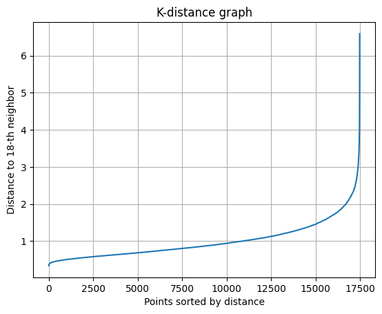

```python
num_features = X.shape[1]
n_neighbors = 2 * num_features
nn = NearestNeighbors(n_neighbors=n_neighbors)
nn.fit(X)
distances, _ = nn.kneighbors(X)
distances_to_plot = np.sort(distances[:, -1])

plt.plot(distances_to_plot)
plt.ylabel(f"Distance to {n_neighbors}-th neighbor")
plt.xlabel("Points sorted by distance")
plt.title("K-distance graph")
plt.grid(True)
plt.show()
```

Wykres przypomina kształt kolanka. Najpierw powoli rożsnie potem przy 15000 - 17000 punktów bardzo szybko rośnie. Dokładne wyznaczenie tego punktu jest trudne, bo wykres nie ma ostrego jednego punktu załamania zmiana nachylenia następuje płynnie. Punkt przegięcia to pewnie tak około 16k

Taka heurystyczna metoda jest wykorzystywana w wielu przypadkach doboru hiperparametrów w klasteryzacji. Zasadnicza idea jest taka, że punkt przegięcia odpowiada momentowi, gdzie dane zaczynają wyraźnie rozróżniać się od siebie i tworzyć wyraźne grupy. Jest to proste i szybkie, ale jest dość nieprecyzyjne w porównaniu do innych metod (jeżeli w ogóle istnieją dla danego zadania!). Jeżeli chcemy zrobić walidację skrośną, korzystając z jakiejś metryki, to taki wykres daje nam sensowny punkt wyjścia do zakresu hiperparametru.

Warto też pamiętać, że klasteryzacja to proces z natury interaktywny. Takie wykresy są ważne, bo zwiększają naszą intuicję, ale np. dokładne dobranie wartości jest typowo robione ręcznie.

**Zadanie 5 (1.5 punktu)**

Wytrenuj DBSCAN z promieniem epsilon wyznaczonym z wykresu i min_samples równym 2 razy liczbie cech. W razie potrzeby zmniejsz lub zwiększ epsilon, aby uzyskać wyniki, które wydają się sensowne (liczba klastrów, procent szumu, CH-index).

Dokonaj analizy wyjściowych klastrów. Czy finalna ich liczba oraz procent szumu są sensowne? Czy klastry są lepiej widoczne, lub lepiej interpretowalne, niż w przypadku k-means?

```
Number of clusters: 5
Percentage of noise points: 2.18%
CH-index value: 1648.01
```

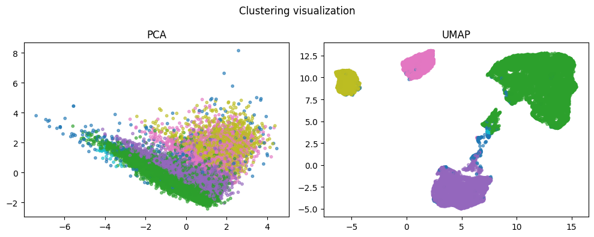

```
Cluster 0 size: 9386
```

|  | Track | Artist |
| --- | --- | --- |
| 0 | Drive (For Daddy Gene) | Alan Jackson |
| 1 | You and I | Wilco |
| 2 | Odhani (From "Made in China") | Sachin-Jigar |
| 3 | Higher Place - Radio Edit | Dimitri Vegas & Like Mike |
| 4 | Penny Lane - Remastered 2009 | The Beatles |
| 5 | Rather Be (feat. Jess Glynne) | Clean Bandit |
| 6 | Lay It All on Me (feat. Ed Sheeran) | Rudimental |
| 7 | I'd Rather | Luther Vandross |
| 8 | Death On Two Legs (Dedicated To...) - Remaster... | Queen |
| 9 | Harness Your Hopes - B-side | Pavement |

```
Top 10 genres in the cluster: ['rock', 'pop', 'dance pop', 'post-teen pop', 'classic rock', 'mellow gold', 'soft rock', 'pop rock', 'album rock', 'modern rock']
Cluster 1 size: 4342
```

|  | Track | Artist |
| --- | --- | --- |
| 0 | The Sun | Parov Stelar |
| 1 | Until The End Of Time (with Beyoncé) | Justin Timberlake |
| 2 | Princesse | Nekfeu |
| 3 | Favours | Hayden James |
| 4 | OK | Robin Schulz |
| 5 | Foreplay | Jalen Santoy |
| 6 | React | The Pussycat Dolls |
| 7 | Secret Door | Arctic Monkeys |
| 8 | Somewhere With You | Kenny Chesney |
| 9 | Greek Tragedy - Oliver Nelson TikTok Remix | The Wombats |

```
Top 10 genres in the cluster: ['pop', 'dance pop', 'rock', 'post-teen pop', 'modern rock', 'classic rock', 'pop dance', 'edm', 'tropical house', 'album rock']
Cluster 2 size: 1822
```

|  | Track | Artist |
| --- | --- | --- |
| 0 | Worst Behavior | Drake |
| 1 | Broken Clocks | SZA |
| 2 | just like magic | Ariana Grande |
| 3 | Augenblick (feat. Summer Cem) | KC Rebell |
| 4 | All Night (feat. Knox Fortune) | Chance the Rapper |
| 5 | Luxury | Azealia Banks |
| 6 | These Walls | Kendrick Lamar |
| 7 | okay | LANY |
| 8 | Omar | Koba LaD |
| 9 | Gang | Mister V |

```
Top 10 genres in the cluster: ['rap', 'hip hop', 'pop rap', 'pop', 'trap', 'gangster rap', 'southern hip hop', 'dance pop', 'east coast hip hop', 'post-teen pop']
Cluster 3 size: 1519
```

|  | Track | Artist |
| --- | --- | --- |
| 0 | Soleil | Roméo Elvis |
| 1 | A$AP Forever REMIX (feat. Moby, T.I. & Kid Cudi) | A$AP Rocky |
| 2 | A$AP Forever (feat. Moby) | A$AP Rocky |
| 3 | beibs in the trap | Travis Scott |
| 4 | Like That (feat. Gucci Mane) | Doja Cat |
| 5 | Why Do You Lie To Me (feat. Lil Baby) | Topic |
| 6 | Facetime | Dardan |
| 7 | Calumet | Hornet La Frappe |
| 8 | SIDECHICKZ | Apache 207 |
| 9 | 1994 | Hamza |

```
Top 10 genres in the cluster: ['rap', 'hip hop', 'pop rap', 'trap', 'pop', 'gangster rap', 'dance pop', 'southern hip hop', 'r&b', 'east coast hip hop']
```

```python
n_features = X.shape[1]
eps = 1.80
min_samples = 2 * n_features

dbscan = DBSCAN(eps=eps, min_samples=min_samples, n_jobs=-1)
dbscan.fit(X)

dbscan_analyzer = DBSCANAnalyzer(df_songs_info, clustering_visualizer)
dbscan_analyzer.analyze_clustering(X, dbscan)
```

Klasteryzacja jest teraz o wiele lepsza szczególnie w przypadku UMAP. Na widać 4 różne duże klastry ładnie odseparowane od siebie 4 klastry szumu jest około 2% wiec nie dużo.

DBSCAN ma dwie zasadnicze wady: trudny dobór hiperparametrów oraz podatność na szum. W szczególności to drugie widać, jeżeli w naszym zbiorze ciągle znajduje on dużo szumu - to oznaka, że mamy zmienną gęstość w danych i przydałoby się coś adaptacyjnego, jak OPTICS albo HDBSCAN. OPTICS jest bardziej zoptymalizowany pod pamięć niż szybkość w scikit-learn, plus ma raczej nieintuicyjne hiperparametry (może nawet bardziej, niż DBSCAN), więc wykorzystamy tutaj HDBSCAN.

Jego głównym hiperparametrem jest `min_cluster_size`, czyli po prostu minimalna liczba punktów, aby stworzyć klaster. Dodatkowo `min_samples` ma takie samo znaczenie, jak w DBSCAN, czyli jest to minimalna liczba punktów, aby utworzyć punkt typu CORE. Domyślnie są one równe, ale oczywiście można ustawić `min_samples` (sporo) mniejsze od `min_cluster_size`, i dostrajać oba.

```
Number of clusters: 6
Percentage of noise points: 1.27%
CH-index value: 1246.59
```

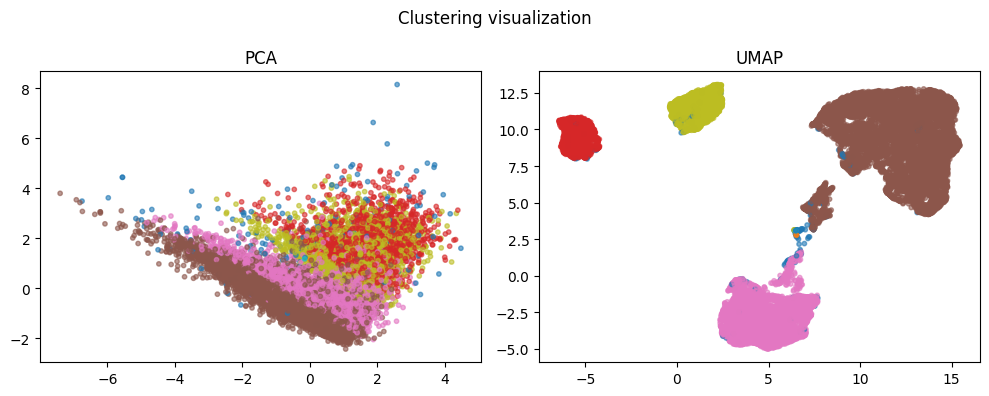

```
Cluster 2 size: 9476
```

|  | Track | Artist |
| --- | --- | --- |
| 0 | Bewitched, Bothered, And Bewildered | Ella Fitzgerald |
| 1 | I'll Look Around | Billie Holiday |
| 2 | Love Is Here To Stay - Remastered 1998 | Frank Sinatra |
| 3 | I Get Along Without You Very Well (Except Some... | Chet Baker |
| 4 | It's Always You - Vocal Version | Chet Baker |
| 5 | Banana Boat (Day-O) | Harry Belafonte |
| 6 | remember the mornings | Clinton Kane |
| 7 | Meet Again | KIMSEJEONG |
| 8 | blind | ROLE MODEL |
| 9 | Mack the Knife | Louis Armstrong |

```
Top 10 genres in the cluster: ['rock', 'pop', 'dance pop', 'classic rock', 'post-teen pop', 'mellow gold', 'soft rock', 'pop rock', 'album rock', 'modern rock']
Cluster 3 size: 4407
```

|  | Track | Artist |
| --- | --- | --- |
| 0 | Beyond the Sea | Bobby Darin |
| 1 | You Send Me - Mono | Sam Cooke |
| 2 | Jailhouse Rock | Elvis Presley |
| 3 | Fingers Crossed | Agnes |
| 4 | Going Dumb | Alesso |
| 5 | Bazaar - Official Sunburn Goa 2015 Anthem | KSHMR |
| 6 | Start A Riot | BANNERS |
| 7 | Talk | Why Don't We |
| 8 | What They'll Say About Us | FINNEAS |
| 9 | All of Me | Billie Holiday |

```
Top 10 genres in the cluster: ['pop', 'dance pop', 'rock', 'post-teen pop', 'modern rock', 'classic rock', 'pop dance', 'edm', 'tropical house', 'album rock']
Cluster 4 size: 1811
```

|  | Track | Artist |
| --- | --- | --- |
| 0 | Come And Get It | I Prevail |
| 1 | Introversion 2.0 | $uicideboy$ |
| 2 | Emergency | Icona Pop |
| 3 | Playlist | Ufo361 |
| 4 | High | Sido |
| 5 | Ain't No Fun (If the Homies Cant Have None) (f... | Snoop Dogg |
| 6 | Killing In the Name | Rage Against The Machine |
| 7 | Take The Power Back | Rage Against The Machine |
| 8 | Bitches Ain't Shit | Dr. Dre |
| 9 | Bombtrack | Rage Against The Machine |

```
Top 10 genres in the cluster: ['rap', 'hip hop', 'pop rap', 'pop', 'trap', 'gangster rap', 'southern hip hop', 'dance pop', 'post-teen pop', 'east coast hip hop']
Cluster 1 size: 1543
```

|  | Track | Artist |
| --- | --- | --- |
| 0 | You | Candlebox |
| 1 | Wu-Tang Clan Ain't Nuthing ta F' Wit | Wu-Tang Clan |
| 2 | You Know How We Do It - Remastered | Ice Cube |
| 3 | Different | Hippie Sabotage |
| 4 | A$AP Forever (feat. Moby) | A$AP Rocky |
| 5 | A$AP Forever REMIX (feat. Moby, T.I. & Kid Cudi) | A$AP Rocky |
| 6 | shining on my ex | bbno$ |
| 7 | Hope You Do | Chris Brown |
| 8 | The Break Up | Machine Gun Kelly |
| 9 | I Wanna Be Somebody | W.A.S.P. |

```
Top 10 genres in the cluster: ['rap', 'hip hop', 'pop rap', 'trap', 'pop', 'gangster rap', 'dance pop', 'southern hip hop', 'east coast hip hop', 'r&b']
```

```python
clustering = HDBSCAN()
clustering.fit(X)

dbscan_analyzer = HDBSCANAnalyzer(df_songs_info, clustering_visualizer)
dbscan_analyzer.analyze_clustering(X, clustering)
```

Domyślne `min_cluster_size` to zaledwie 5, a mimo tego HDBSCAN wcale nie znalazł tak dużo klastrów - pokazuje to jego zdolność do adaptacji do zbioru danych. CH-index nie jest zbyt wysoki, pomimo tego, że niektóre klastry wydają się ciekawe i inne niż w k-means. Pokazuje to też, że klastry pewnie nie są sferyczne.

**Zadanie 6 (2 punkty)**

Dokonaj ręcznego tuningu hiperparametrów `min_cluster_size` oraz `min_samples`. Pamiętaj, że przy stałym `min_samples` możesz praktycznie za darmo zmieniać `min_cluster_size` dzięki cache'owaniu.

Skomentuj finalne wyniki. Czy udało się uzyskać sensowne, interpretowalne klastry? Czy są one w jakimś stopniu nieoczywiste, tj. czy otrzymaliśmy jakąś nową wiedzę dzięki klasteryzacji? Czy CH-index wskazał sensownie na jakość klasteryzacji w HDBSCAN?

```
Number of clusters: 4
Percentage of noise points: 4.77%
CH-index value: 2184.66
```

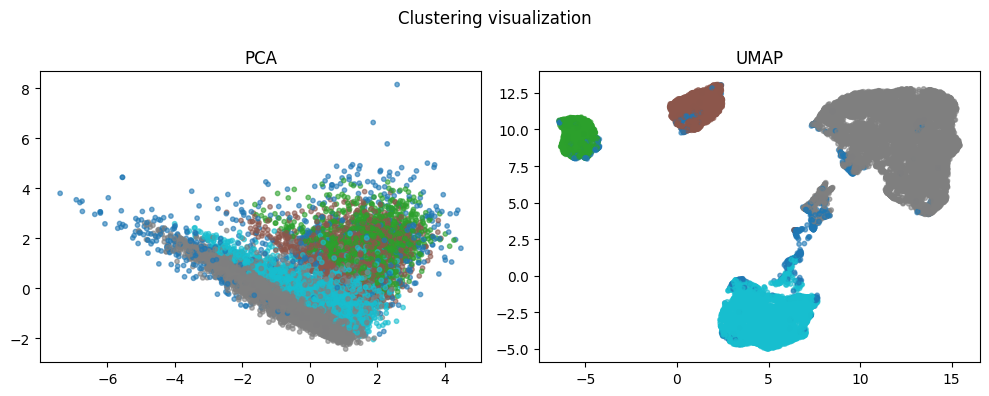

```
Cluster 2 size: 9243
```

|  | Track | Artist |
| --- | --- | --- |
| 0 | Mandy | Westlife |
| 1 | Lonely (with Jonas Brothers) | Diplo |
| 2 | Tus Ojos | Belanova |
| 3 | Drinkin' Bone | Tracy Byrd |
| 4 | The Rising | Bruce Springsteen |
| 5 | Brokenheartsville | Joe Nichols |
| 6 | No Dices Mas | Mœnia |
| 7 | I Live My Life for You | Firehouse |
| 8 | This One's for the Girls | Martina McBride |
| 9 | Devil on My Shoulder | Billy Talent |

```
Top 10 genres in the cluster: ['rock', 'pop', 'dance pop', 'post-teen pop', 'classic rock', 'mellow gold', 'soft rock', 'pop rock', 'album rock', 'modern rock']
Cluster 3 size: 4224
```

|  | Track | Artist |
| --- | --- | --- |
| 0 | On The Beach | Jubël |
| 1 | Red | Taylor Swift |
| 2 | Lies | MK |
| 3 | Do You Remember The First Time? | Pulp |
| 4 | Beggin (original version) | Madcon |
| 5 | BBoom BBoom | MOMOLAND |
| 6 | Glad You Came | The Wanted |
| 7 | Love Again | Dua Lipa |
| 8 | Giant (with Rag'n'Bone Man) | Calvin Harris |
| 9 | Last Dance | Dua Lipa |

```
Top 10 genres in the cluster: ['pop', 'dance pop', 'rock', 'post-teen pop', 'modern rock', 'pop dance', 'classic rock', 'edm', 'tropical house', 'album rock']
Cluster 1 size: 1738
```

|  | Track | Artist |
| --- | --- | --- |
| 0 | Free | 6LACK |
| 1 | Summer Cem (feat. Luciano) | Summer Cem |
| 2 | I Bet | Ciara |
| 3 | Only God Knows Why | Kid Rock |
| 4 | Menage A Trois | LIZOT |
| 5 | False Confidence | Noah Kahan |
| 6 | All Your Exes | Julia Michaels |
| 7 | Heat (feat. Gunna) | Chris Brown |
| 8 | Let the Games Begin | AJR |
| 9 | Chulin Culin Chunfly | Voltio |

```
Top 10 genres in the cluster: ['rap', 'hip hop', 'pop rap', 'pop', 'trap', 'gangster rap', 'southern hip hop', 'dance pop', 'post-teen pop', 'east coast hip hop']
Cluster 0 size: 1432
```

|  | Track | Artist |
| --- | --- | --- |
| 0 | WHAT TO DO? (feat. Don Toliver) | JACKBOYS |
| 1 | Lemonade (feat. Gunna, Don Toliver & NAV) | Internet Money |
| 2 | Ghost Town | Adam Lambert |
| 3 | Angel | The Weeknd |
| 4 | Christian Dior | Jhay Cortez |
| 5 | Finesse Out The Gang Way (feat. Lil Baby) | Lil Durk |
| 6 | Beef | Apache 207 |
| 7 | Incomplete | Sisqo |
| 8 | CASINO ROYAL | Kianush |
| 9 | Outta Control - Remix | 50 Cent |

```
Top 10 genres in the cluster: ['rap', 'hip hop', 'pop rap', 'trap', 'pop', 'gangster rap', 'dance pop', 'southern hip hop', 'r&b', 'east coast hip hop']
```

```python
min_cluster_size = 80
min_samples = 25

hdbscan = HDBSCAN(min_cluster_size=min_cluster_size, min_samples=min_samples)
hdbscan.fit(X)

hdbscan_analyzer = HDBSCANAnalyzer(df_songs_info, clustering_visualizer)
hdbscan_analyzer.analyze_clustering(X, hdbscan)
```

Tak bo liczba klastrów jest niewielka i są wyraźnie oddzielone (potwierdza to też niski % szumu). Analiza top gatunków z danego klastra potwierdza sensowność klastrów w jednym mamy gatunki rapo podobne w innym bardziej popowe. CH-index value: 2184.66 wartość CH-index wyszła całkiem wysoka, co sugeruje, że klastry są dość zwarte i dobrze oddzielone.

## Zadanie dodatkowe (3 punkty)

Klasteryzacja hierarchiczna jest przydatnym narzędziem, dającym od razu znaczną ilość informacji co do klasteryzacji, ale ze względu na złożoność nadaje się tylko do mniejszych zbiorów danych. Takim zbiorem jest dobrze nam już znany [Ames housing](https://www.openintro.org/book/statdata/?data=ames).

1. Załaduj zbiór i dokonaj odpowiedniego preprocessingu. Zwizualizuj go z pomocą PCA oraz UMAP.
2. Zastosuj klasteryzację hierarchiczną do tego zbioru, wykorzystując metrykę euklidesową i Ward linkage.
3. Narysuj dendrogram dla wynikowej klasteryzacji. Czy widać jakąś strukturę klastrującą? Sprawdź kilka przykładowych próbek, które wydają się podobne - czy faktycznie te domy są podobne?
4. Wybierz klasteryzację, która wydaje się najbardziej stabilna, tj. ma najdłuższe pionowe linie na dendrogramie. Sprawdź jej CH-index, oraz zwizualizuj ją za pomocą PCA oraz UMAP. Ile ma ona klastrów? Czy wydaje się ona sensowna? Wypisz przykładowe domy z klastrów. Czy faktycznie wskazują na zróżnicowanie klastrów?
5. Porównaj tę klasteryzację z k-means (dokonaj tuningu liczby klastrów z pomocą CH-index) oraz HDBSCAN. Ile klastrów wybrały te metody? Czy na wizualizacji PCA i UMAP dają lepsze, czy gorsze wyniki od klasteryzacji hierarchicznej?